# Probability and Statistical Inference

### Section A

We have the IQ of a sample of 5 subjects: 110 100 115 105 104

We want to:

- Case 1: Calculate the confidence interval above the mean (95%).

```r
iq <- c(110,100,115,105,104)
# Calculate the confidence interval
t.test(iq)
```

```
    One Sample t-test

data:  iq
t = 41.138, df = 4, p-value = 2.087e-06
alternative hypothesis: true mean is not equal to 0
95 percent confidence interval:
  99.59193 114.00807
sample estimates:
mean of x
    106.8
```

The confidence interval (95%) is: [99.59193, 114.00807].

- Case 2: Indicate if this subjects have been extracted of a population with mean = 100.

```r
# Calculate if the mean is equal to 100
t.test(iq, mu=100, conf.level = 0.99)
```

```
    One Sample t-test

data:  iq
t = 2.6193, df = 4, p-value = 0.05884
alternative hypothesis: true mean is not equal to 100
99 percent confidence interval:
  94.84707 118.75293
sample estimates:
mean of x
    106.8
```

As the `p-value > 0.05`, then it is supossed that the subjects’s population has mean = 100.

### Section B

With the dataset `survey`, we want to contrast if the pulse difference between men and women is different or not. Could it considered that the women pulse is higher than the men pulse with a confidence level of 90%?

```r
library(MASS)
head(survey)
```

|  | Sex | Wr.Hnd | NW.Hnd | W.Hnd | Fold | Pulse | Clap | Exer | Smoke | Height | M.I | Age |
| --- | --- | --- | --- | --- | --- | --- | --- | --- | --- | --- | --- | --- |
| 1 | Female | 18.5 | 18.0 | Right | R on L | 92 | Left | Some | Never | 173.00 | Metric | 18.250 |
| 2 | Male | 19.5 | 20.5 | Left | R on L | 104 | Left | None | Regul | 177.80 | Imperial | 17.583 |
| 3 | Male | 18.0 | 13.3 | Right | L on R | 87 | Neither | None | Occas | NA | NA | 16.917 |
| 4 | Male | 18.8 | 18.9 | Right | R on L | NA | Neither | None | Never | 160.00 | Metric | 20.333 |
| 5 | Male | 20.0 | 20.0 | Right | Neither | 35 | Right | Some | Never | 165.00 | Metric | 23.667 |
| 6 | Female | 18.0 | 17.7 | Right | L on R | 64 | Right | Some | Never | 172.72 | Imperial | 21.000 |

The dataset contains `NA` values. We omit them:

```r
data <- na.omit(survey)
# Let's see the difference in means:
t.test(Pulse ~ Sex, data, conf.level = 0.9)
```

```
    Welch Two Sample t-test

data:  Pulse by Sex
t = 0.82842, df = 164.02, p-value = 0.4086
alternative hypothesis: true difference in means is not equal to 0
90 percent confidence interval:
 -1.471497  4.423878
sample estimates:
mean in group Female   mean in group Male
            74.76190             73.28571
```

```r
t.test(Pulse ~ Sex, data, alternative = "g", conf.level = 0.90)
```

```
    Welch Two Sample t-test

data:  Pulse by Sex
t = 0.82842, df = 164.02, p-value = 0.2043
alternative hypothesis: true difference in means is greater than 0
90 percent confidence interval:
 -0.816699       Inf
sample estimates:
mean in group Female   mean in group Male
            74.76190             73.28571
```

With these results, the difference between the pulse mean of both sex is not 0 and either greater 0. Therefore, we cannot say if the women pulse is greater than the men pulse.

### Section C

**Ley de Benford** The Xdata company has sent me a bills which seem to be false. These bills has a lot of numbers which does not seem to generated with a natural mode. We check if this bill is generated artificially with the Benford law (https://es.wikipedia.org/wiki/Ley_de_Benford). The Benford law sets that the natural distribution of the first digits is:

```
  0.301,0.176,0.125,0.097,0.079,0.067,0.058,0.051,0.046
```

The frequencies of the first digits of the company bills are:

```
  7, 13, 12,  9,  9, 13, 11, 10, 16
```

¿Are the bills falses?

```r
# Probabilities of the first digits (Benford)
prob <- c(0.301,0.176,0.125,0.097,0.079,0.067,0.058,0.051,0.046)
# Frequencies of the first digits (Xdata bills)
freq <- c(7, 13, 12,  9,  9, 13, 11, 10, 16)
# Check if they are dependients with probabilities
chisq.test(freq, p = prob)
```

```
Chi-squared approximation may be incorrect
```

```
    Chi-squared test for given probabilities

data:  freq
X-squared = 62.7, df = 8, p-value = 1.373e-10
```

As the `p-value < 0.05`, the distributions cannot be considered the same. Thus, the bills do not comply with Benford law and are potentially falses.

### Section D

With this dataset:

```r
data("PlantGrowth")
PlantGrowth
```

| weight | group |
| --- | --- |
| 4.17 | ctrl |
| 5.58 | ctrl |
| 5.18 | ctrl |
| 6.11 | ctrl |
| 4.50 | ctrl |
| 4.61 | ctrl |
| 5.17 | ctrl |
| 4.53 | ctrl |
| 5.33 | ctrl |
| 5.14 | ctrl |

[output cut: 20 more lines]

- Could it considered that with the three treatments, the plants have the same growth?

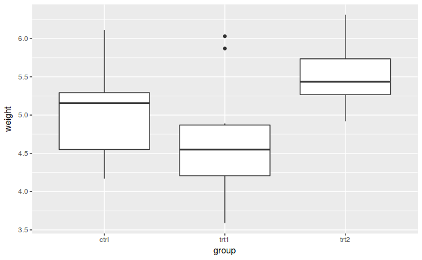

```r
# We are going to a exploratory analysis for seeing its behaviour:
library(ggplot2)
ggplot(PlantGrowth, aes(x = group, y = weight)) +
  geom_boxplot()
```

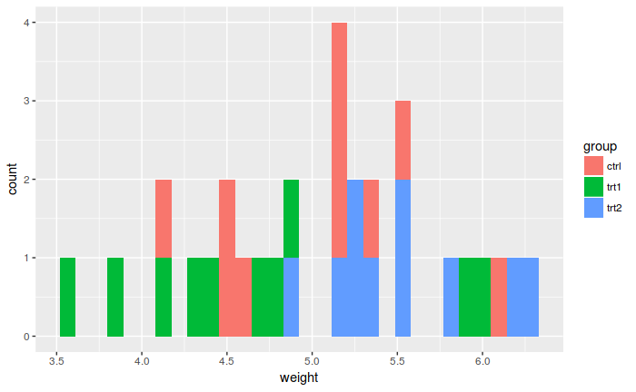

```r
ggplot(PlantGrowth, aes(x = weight, fill = group)) +
  geom_histogram()
```

As we can see, the three treatments have not the same growth above the plants.

- Make the one-way ANOVA. What could conclusions infer of this way?

Let’s see if the groups are not equals

```r
oneway.test(weight ~ group, PlantGrowth)
```

```
    One-way analysis of means (not assuming equal variances)

data:  weight and group
F = 5.181, num df = 2.000, denom df = 17.128, p-value = 0.01739
```

As the groups are not equals, let’s see if there is any difference between `ctrl` and `trt1` treatments

```r
ctrl_trt1 <- PlantGrowth[PlantGrowth$group != "trt2", ]
ctrl_trt1
```

|  | weight | group |
| --- | --- | --- |
| 1 | 4.17 | ctrl |
| 2 | 5.58 | ctrl |
| 3 | 5.18 | ctrl |
| 4 | 6.11 | ctrl |
| 5 | 4.50 | ctrl |
| 6 | 4.61 | ctrl |
| 7 | 5.17 | ctrl |
| 8 | 4.53 | ctrl |
| 9 | 5.33 | ctrl |
| 10 | 5.14 | ctrl |

[output cut: 10 more lines]

```r
oneway.test(weight ~ group, ctrl_trt1)
```

```
    One-way analysis of means (not assuming equal variances)

data:  weight and group
F = 1.4191, num df = 1.000, denom df = 16.524, p-value = 0.2504
```

With this result, we can say that the `ctrl` and `trt1` are the same. We are going to make it sure.

```r
new_data <- PlantGrowth
new_data[new_data$group == "ctrl", "group"] <- "trt1"
new_data
```

| weight | group |
| --- | --- |
| 4.17 | trt1 |
| 5.58 | trt1 |
| 5.18 | trt1 |
| 6.11 | trt1 |
| 4.50 | trt1 |
| 4.61 | trt1 |
| 5.17 | trt1 |
| 4.53 | trt1 |
| 5.33 | trt1 |
| 5.14 | trt1 |

[output cut: 20 more lines]

```r
oneway.test(weight ~ group, new_data)
```

```
    One-way analysis of means (not assuming equal variances)

data:  weight and group
F = 10.406, num df = 1.000, denom df = 26.265, p-value = 0.003352
```

With this: `p-value < 0.05`, we make sure that there are only two treatments: `trt1` and `trt2`.